# Do developers trust AI? Adoption, attitudes and pay in the 2025 Stack Overflow Developer Survey

A complex data analysis in R

03 October 2026

# 1 Introduction

AI coding assistants moved from novelty to default tooling in about three years. This report uses the **Stack Overflow Annual Developer Survey 2025** (44,682 professional developers after cleaning, 175 countries) to ask who actually adopts them, who trusts them, and whether any of it shows up in pay.

## 1.1 Research questions

| # | Question | Method |
| --- | --- | --- |
| RQ1 | Does AI tool adoption depend on developer role and experience? | Chi-square, logistic regression |
| RQ2 | Do AI users earn more than non-users? | Welch t-test, Wilcoxon, linear regression |
| RQ3 | Does trust in AI accuracy change with experience? | Chi-square, test for trend |
| RQ4 | Can AI adoption be predicted from professional attributes? | Six-model benchmark with ROC/AUC, DeLong and McNemar tests |
| RQ5 | Are there distinct developer “personas” in AI attitudes? | k-means, silhouette, resampling stability |

## 1.2 Key findings

1. **Adoption is near-universal but shallow in trust.** 79.4% use AI tools and 48.1% use them daily, yet only 32.4% say they trust the accuracy of what those tools produce.
2. **Both adoption and trust fall as experience rises.** Adoption drops from 88.5% among developers with 0-2 years of experience to 72.7% among those with 20+ years (chi-square test for trend, p < 0.001).
3. **AI users earn slightly *less*, not more.** Median $76,097 versus $81,685 (Cohen’s d = -0.16). The gap is a small effect and is not present once experience, region and the other covariates are controlled.
4. **Pay is mostly explained by geography, experience and education.** The linear model reaches R² = 0.443; AI use contributes almost nothing once those are in the model.
5. **Adoption is hard to predict from professional attributes.** Across 6 benchmarked models the best held-out AUC is 0.666 (XGBoost), and no model is reliably better than logistic regression after Holm correction.
6. **Trust tracks usage, not seniority in isolation.** An ordinal (proportional-odds) model on the full five-point trust scale puts daily users at 11.2x the odds of higher trust versus respondents who do not currently use AI tools, while each additional year of experience multiplies those odds by 0.969.
7. **The complaint is precision, not capability.** 67% name “AI solutions that are almost right, but not quite” as a frustration, and 46% say debugging AI-generated code is more time-consuming than writing it themselves.
8. **Developers split into two overlapping camps.** k-means finds 2 clusters: an AI-embracing group (54.5% of respondents, 87% daily users) and a sceptical group (45.5%, 24% daily users). The sceptics have a higher median salary ($83,668 versus $73,686) — salary was never used to build the clusters.

## 1.3 Data and licence

Stack Overflow Annual Developer Survey 2025, CC BY-SA 4.0, https://survey.stackoverflow.co/. The raw file holds 172 columns; the cleaning script keeps 38 after feature engineering and restricts the sample to respondents who are developers by profession or who write code as part of their work.

# 2 Data preparation

The raw export needs real work before it can be analysed:

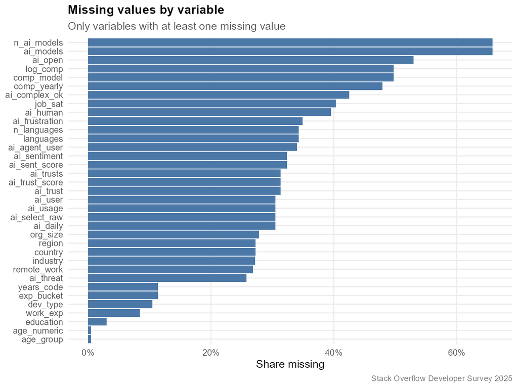

Missing values by variable

```r
fig("01_missingness")
```

Missingness is concentrated in the optional free-text and compensation fields, which is why every model states the row count it actually fits on.

# 3 Exploratory analysis

```r
kable(read_out("02_overview"), caption = "Sample at a glance")
```

Sample at a glance

| metric | value |
| --- | --- |
| Respondents | 44682.0 |
| Countries | 175.0 |
| Median years coding | 15.0 |
| Median salary (USD, outliers removed) | 77987.0 |
| AI tool users (%) | 79.4 |
| Daily AI users (%) | 48.1 |
| Trust AI accuracy (%) | 32.4 |

## 3.1 Compensation

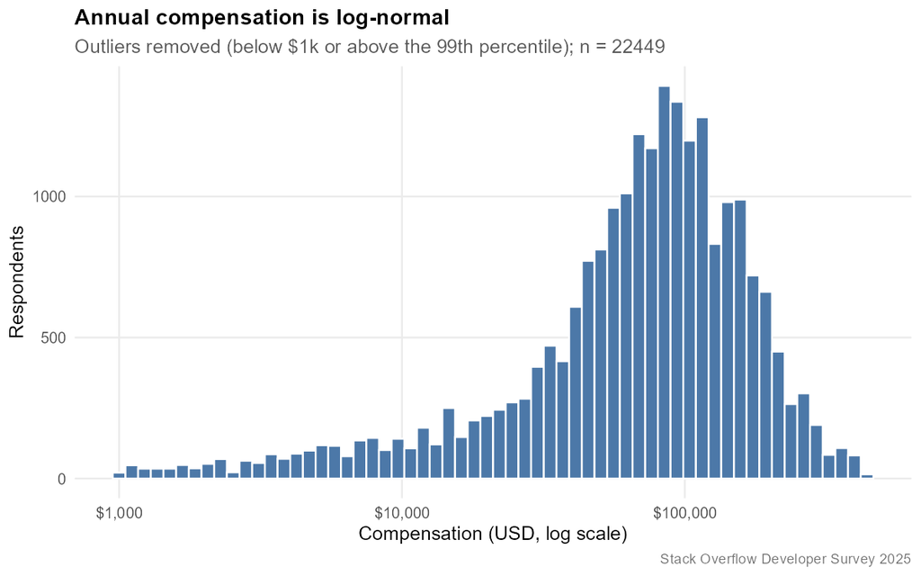

Compensation distribution

```r
fig("02_salary_distribution")
```

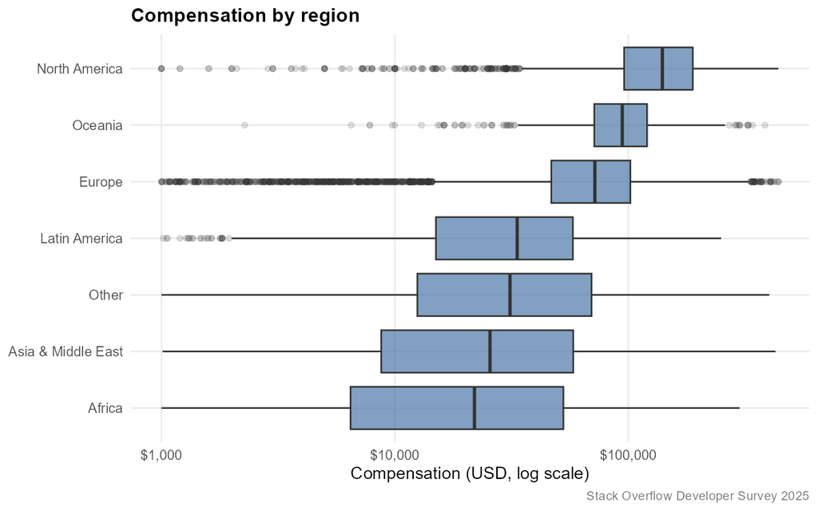

Compensation by region

```r
fig("03_salary_by_region")
```

## 3.2 AI adoption and attitudes

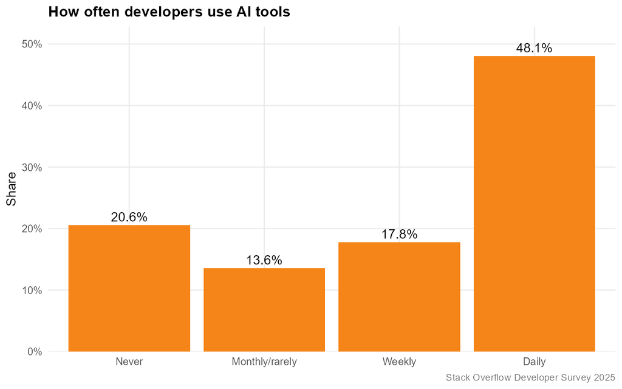

AI tool usage frequency

```r
fig("04_ai_usage")
```

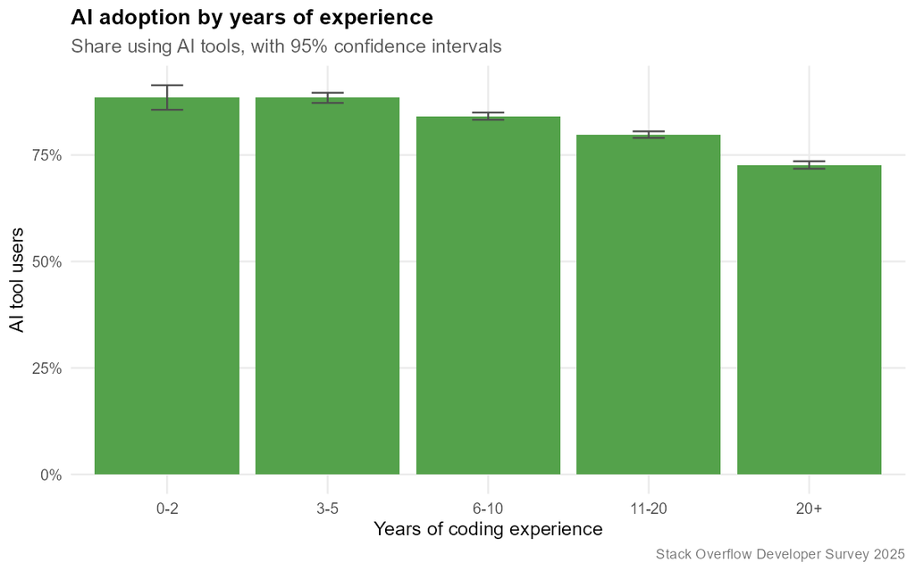

Adoption by experience

```r
fig("05_adoption_by_experience")
```

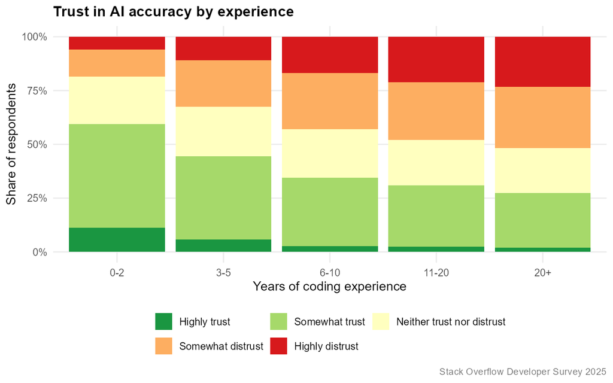

Trust by experience

```r
fig("06_trust_by_experience")
```

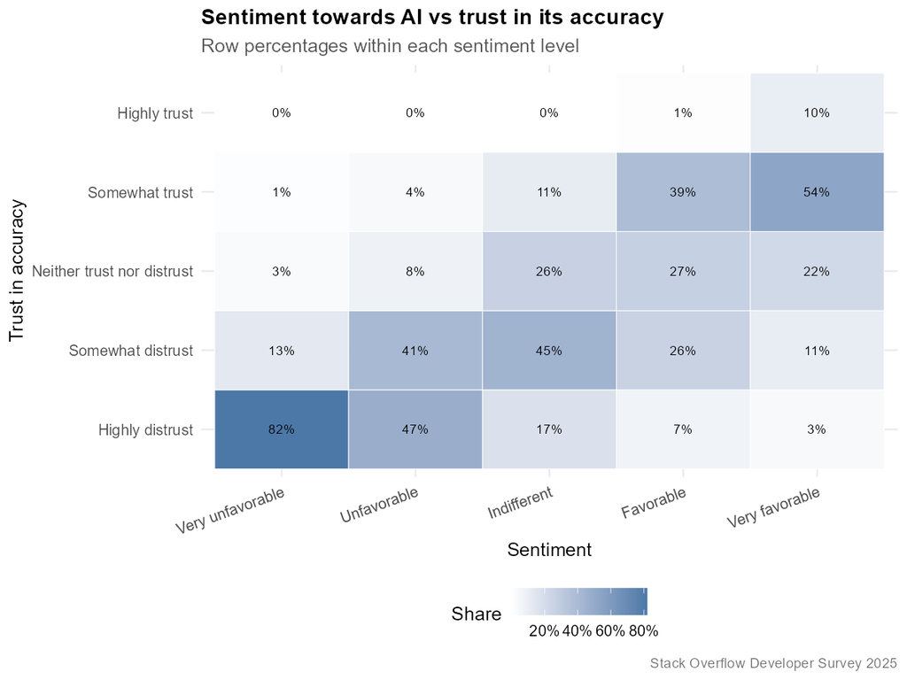

Sentiment vs trust

```r
fig("07_sentiment_vs_trust")
```

Sentiment and trust are related but far from identical: plenty of developers are favourable towards AI while still distrusting its output. That gap is the most interesting single fact in the dataset.

## 3.3 Technology use

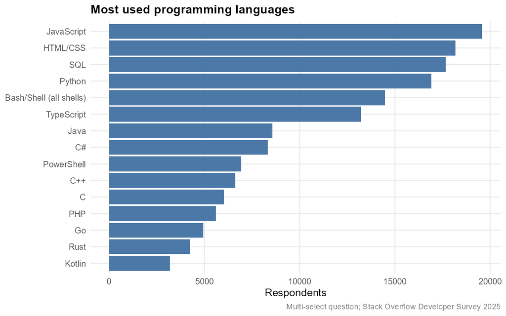

Most used languages

```r
fig("09_top_languages")
```

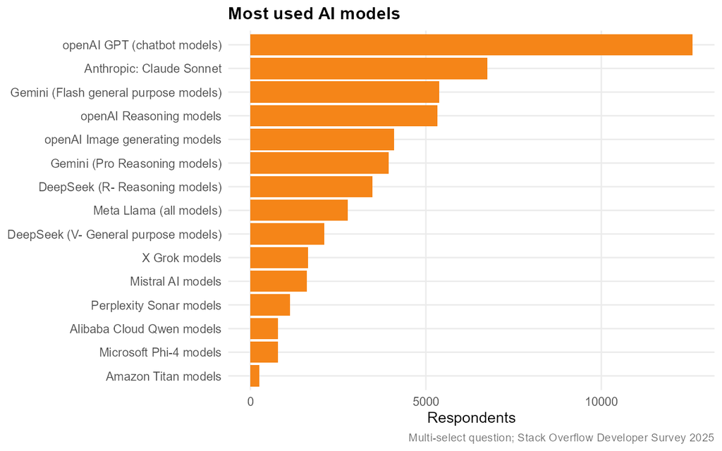

Most used AI models

```r
fig("10_top_ai_models")
```

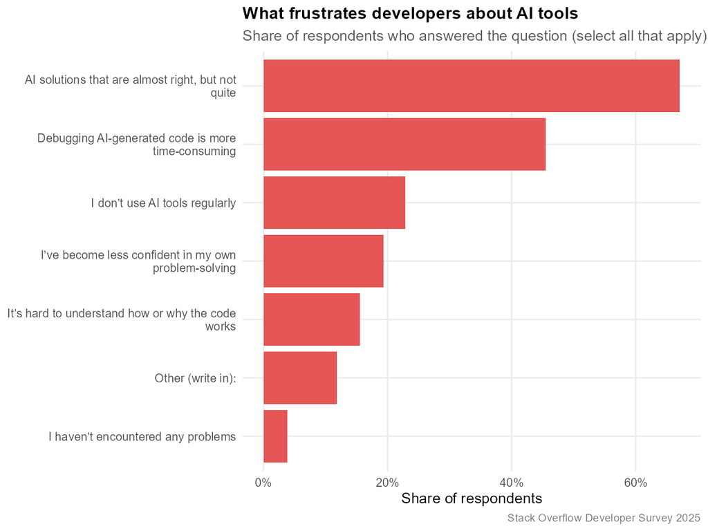

Reported frustrations with AI tools

```r
fig("10b_ai_frustrations")
```

## 3.4 What developers think survives AI

The survey ends with an open question: *“Looking ahead 3-5 years, what skills do you believe will remain valuable for developers even as AI tools become more capable?”* A simple word count over the 17,456 free-text answers shows what people name.

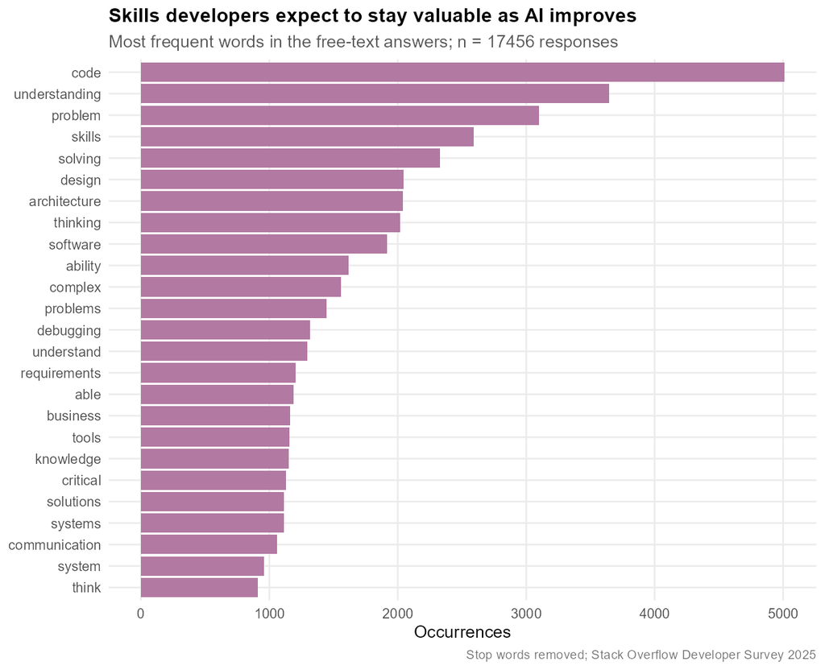

Skills expected to remain valuable

```r
fig("11_ai_open_words")
```

The answers cluster on judgement rather than syntax: understanding, problem solving, architecture, design and debugging. That matches the trust results — developers delegate typing, not deciding.

## 3.5 Correlations

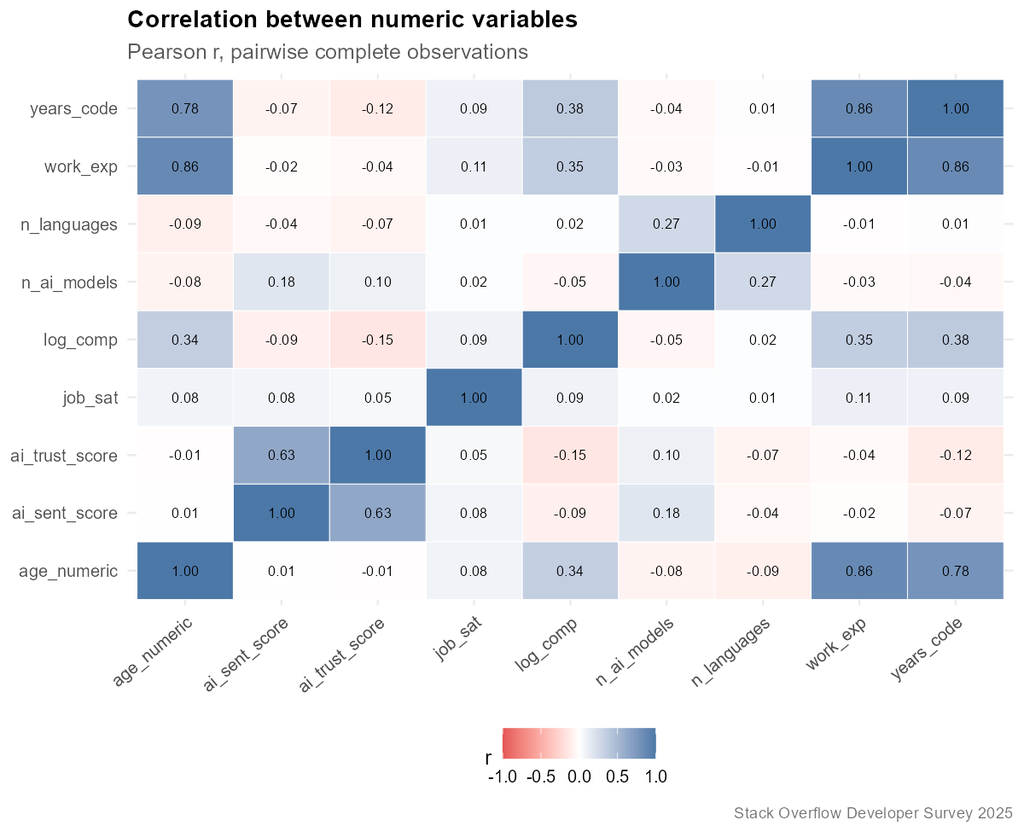

Correlation heatmap

```r
fig("08_correlation_heatmap")
```

# 4 Statistical inference

```r
kable(read_out("09_hypothesis_tests"), caption = "Hypothesis test results")
```

Hypothesis test results

| hypothesis | test | statistic | df | p_value | effect_size | n | p_adjusted | significant |
| --- | --- | --- | --- | --- | --- | --- | --- | --- |
| H1: AI adoption depends on developer role | Chi-square test of independence | 972.162 | 25.000 | < 0.001 | Cramer’s V = 0.177 | 31057 | < 0.001 | TRUE |
| H2: Compensation differs between AI users and non-users | Welch two-sample t-test on log(salary) | -10.845 | 7487.993 | < 0.001 | Cohen’s d = -0.164; 95% CI on log-diff [-0.201, -0.14] | 21842 | < 0.001 | TRUE |
| H2b: Same comparison without the normality assumption | Wilcoxon rank-sum test | 34442132.000 | NA | < 0.001 | rank-biserial r = -0.068 | 21842 | < 0.001 | TRUE |
| H3: Compensation differs across education levels | One-way ANOVA on log(salary) | 82.573 | 3.000 | < 0.001 | eta squared = 0.011 | 22254 | < 0.001 | TRUE |
| H4: Trust in AI accuracy depends on experience | Chi-square test of independence | 465.754 | 4.000 | < 0.001 | Cramer’s V = 0.124 | 30447 | < 0.001 | TRUE |
| H4b: Trust changes monotonically with experience | Chi-square test for trend in proportions | 403.735 | 1.000 | < 0.001 | NA | 30447 | < 0.001 | TRUE |
| H5: Job satisfaction differs for daily AI users | Wilcoxon rank-sum test | 80974594.000 | NA | < 0.001 | rank-biserial r = 0.043 | 24918 | < 0.001 | TRUE |
| H6: Salary response rate depends on region (data not missing at random) | Chi-square test of independence | 919.956 | 6.000 | < 0.001 | Cramer’s V = 0.168 | 32507 | < 0.001 | TRUE |

```r
kable(read_out("09b_tukey_education"),
      caption = "Tukey HSD: pairwise education comparisons on log(salary)")
```

Tukey HSD: pairwise education comparisons on log(salary)

| comparison | diff | lwr | upr | p adj |
| --- | --- | --- | --- | --- |
| Bachelor’s-No degree | 0.1135398 | 0.0653565 | 0.1617231 | 0.00e+00 |
| Master’s-No degree | 0.2579728 | 0.2062111 | 0.3097346 | 0.00e+00 |
| Doctorate/Professional-No degree | 0.3976638 | 0.3125122 | 0.4828155 | 0.00e+00 |
| Master’s-Bachelor’s | 0.1444330 | 0.1018576 | 0.1870085 | 0.00e+00 |
| Doctorate/Professional-Bachelor’s | 0.2841240 | 0.2042229 | 0.3640251 | 0.00e+00 |
| Doctorate/Professional-Master’s | 0.1396910 | 0.0575823 | 0.2217997 | 7.31e-05 |

A note on interpretation: with tens of thousands of respondents, almost anything reaches statistical significance. The effect sizes matter more than the p-values, which is why Cramer’s V, Cohen’s d and eta-squared are reported alongside every test.

# 5 Regression modelling

## 5.1 What predicts salary?

```r
kable(read_out("10_lm_coefficients") %>%
        dplyr::filter(term != "(Intercept)") %>%
        dplyr::arrange(dplyr::desc(abs(estimate))) %>%
        head(15),
      caption = "Linear model on log(salary): largest 15 effects. `pct_effect` is the percentage change in salary.")
```

Linear model on log(salary): largest 15 effects. `pct_effect` is the percentage change in salary.

| term | estimate | std.error | statistic | p.value | conf.low | conf.high | pct_effect |
| --- | --- | --- | --- | --- | --- | --- | --- |
| regionNorth America | 1.7128 | 0.0447 | 38.2963 | 0.0000 | 1.6251 | 1.8005 | 454.4523 |
| regionOceania | 1.3287 | 0.0535 | 24.8455 | 0.0000 | 1.2238 | 1.4335 | 277.5947 |
| regionEurope | 1.0427 | 0.0441 | 23.6669 | 0.0000 | 0.9563 | 1.1291 | 183.6851 |
| dev_typeSenior executive (C-suite, VP, etc.) | 0.8819 | 0.0636 | 13.8669 | 0.0000 | 0.7573 | 1.0066 | 141.5566 |
| dev_typeRetired | -0.8803 | 0.3404 | -2.5862 | 0.0097 | -1.5475 | -0.2131 | -58.5355 |
| dev_typeEngineering manager | 0.8030 | 0.0511 | 15.7181 | 0.0000 | 0.7029 | 0.9031 | 123.2222 |
| dev_typeCloud infrastructure engineer | 0.7493 | 0.0662 | 11.3262 | 0.0000 | 0.6196 | 0.8789 | 111.5460 |
| dev_typeFounder, technology or otherwise | 0.7133 | 0.0835 | 8.5420 | 0.0000 | 0.5496 | 0.8769 | 104.0619 |
| dev_typeAI/ML engineer | 0.6835 | 0.0605 | 11.2896 | 0.0000 | 0.5648 | 0.8022 | 98.0832 |
| dev_typeCybersecurity or InfoSec professional | 0.6369 | 0.0734 | 8.6759 | 0.0000 | 0.4930 | 0.7807 | 89.0519 |
| dev_typeArchitect, software or solutions | 0.6237 | 0.0456 | 13.6906 | 0.0000 | 0.5344 | 0.7130 | 86.5891 |
| dev_typeStudent | -0.5850 | 0.0804 | -7.2792 | 0.0000 | -0.7426 | -0.4275 | -44.2914 |
| dev_typeDevOps engineer or professional | 0.5314 | 0.0512 | 10.3727 | 0.0000 | 0.4310 | 0.6319 | 70.1397 |
| dev_typeDeveloper, back-end | 0.5208 | 0.0424 | 12.2713 | 0.0000 | 0.4376 | 0.6040 | 68.3344 |
| dev_typeData scientist | 0.5116 | 0.0597 | 8.5666 | 0.0000 | 0.3946 | 0.6287 | 66.8033 |

```r
gl <- broom::glance(models$lm)
cat("R-squared:", round(gl$r.squared, 3),
    "| Adjusted:", round(gl$adj.r.squared, 3),
    "| Observations:", gl$nobs)
```

```
## R-squared: 0.443 | Adjusted: 0.442 | Observations: 17940
```

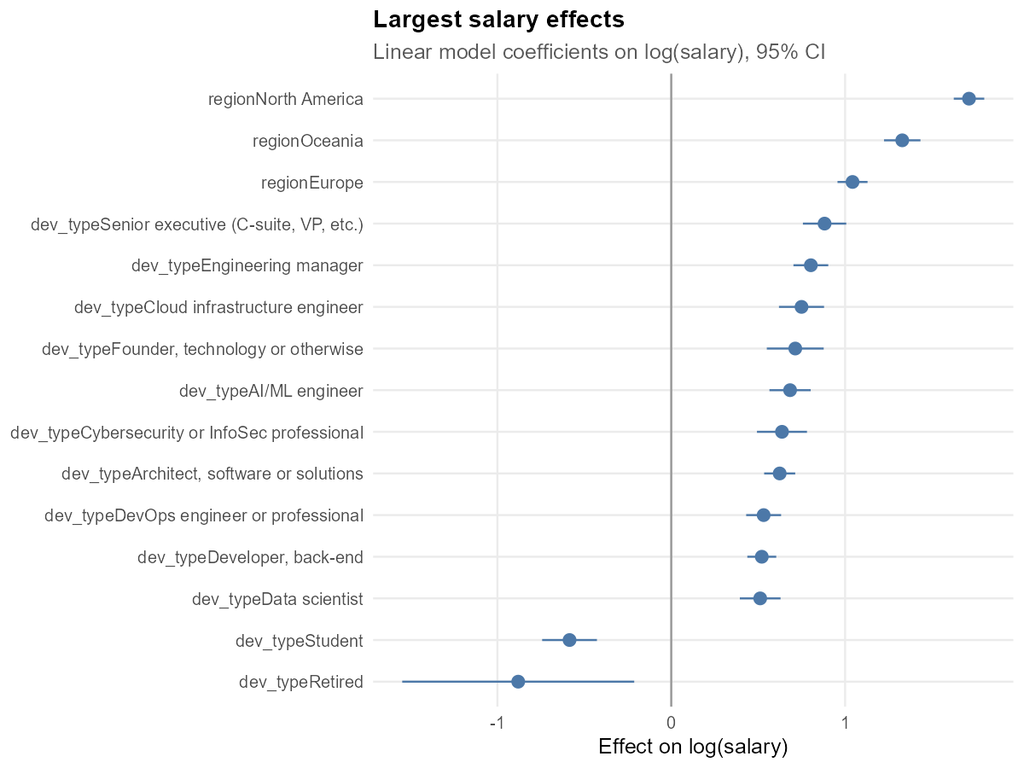

Largest salary effects

```r
fig("14_lm_effects")
```

### 5.1.1 Diagnostics

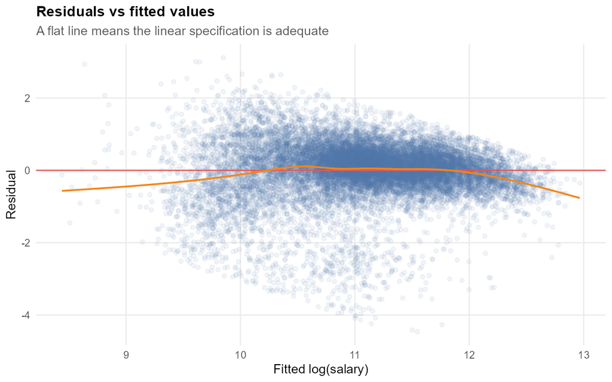

Residuals vs fitted

```r
fig("12_lm_residuals")
```

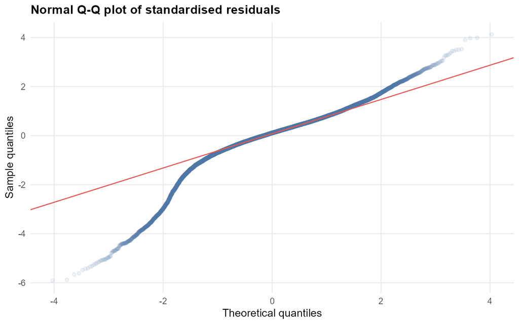

Q-Q plot

```r
fig("13_lm_qq")
```

```r
kable(read_out("11_lm_vif"),
      caption = "Variance inflation factors. GVIF^(1/(2*Df)) above ~2.2 signals collinearity.")
```

Variance inflation factors. GVIF^(1/(2*Df)) above ~2.2 signals collinearity.

| term | gvif | df | gvif_scaled |
| --- | --- | --- | --- |
| years_code | 2.874 | 1 | 1.695 |
| age_numeric | 2.851 | 1 | 1.688 |
| education | 1.342 | 3 | 1.050 |
| region | 1.334 | 6 | 1.024 |
| remote_work | 1.203 | 3 | 1.031 |
| org_size | 1.125 | 2 | 1.030 |
| dev_type | 1.589 | 25 | 1.009 |
| ai_user | 1.053 | 1 | 1.026 |
| n_languages | 1.092 | 1 | 1.045 |

Collinearity is not a problem here (every scaled GVIF is close to 1), but **constant variance is**. The residual plot fans out, and a Breusch-Pagan test confirms it: BP = 1043.6, df = 43, p < 0.001. Ordinary standard errors are therefore wrong — the coefficients stay unbiased, but their precision is overstated.

```r
rob <- read_out("21_lm_robust_se")
kable(rob %>%
        dplyr::arrange(dplyr::desc(se_ratio)) %>%
        head(10) %>%
        dplyr::select(term, estimate, se_classical, se_robust, se_ratio,
                      p_classical, p_robust, flips_at_5pct),
      caption = "HC3 sandwich standard errors versus the classical ones, ten largest ratios.")
```

HC3 sandwich standard errors versus the classical ones, ten largest ratios.

| term | estimate | se_classical | se_robust | se_ratio | p_classical | p_robust | flips_at_5pct |
| --- | --- | --- | --- | --- | --- | --- | --- |
| dev_typeRetired | -0.8803 | 0.3404 | 0.9270 | 2.7234 | 0.0097 | 0.3423 | TRUE |
| regionAsia & Middle East | 0.2830 | 0.0468 | 0.0720 | 1.5397 | 0.0000 | 0.0001 | FALSE |
| regionEurope | 1.0427 | 0.0441 | 0.0676 | 1.5345 | 0.0000 | 0.0000 | FALSE |
| regionNorth America | 1.7128 | 0.0447 | 0.0676 | 1.5108 | 0.0000 | 0.0000 | FALSE |
| regionOther | 0.4334 | 0.0579 | 0.0857 | 1.4818 | 0.0000 | 0.0000 | FALSE |
| regionLatin America | 0.3208 | 0.0498 | 0.0731 | 1.4672 | 0.0000 | 0.0000 | FALSE |
| regionOceania | 1.3287 | 0.0535 | 0.0698 | 1.3059 | 0.0000 | 0.0000 | FALSE |
| (Intercept) | 8.5662 | 0.0690 | 0.0861 | 1.2472 | 0.0000 | 0.0000 | FALSE |
| dev_typeStudent | -0.5850 | 0.0804 | 0.0969 | 1.2060 | 0.0000 | 0.0000 | FALSE |
| n_languages | 0.0010 | 0.0020 | 0.0024 | 1.2019 | 0.6251 | 0.6844 | FALSE |

Robust errors are on average 1.127x the classical ones and 2 coefficients change their verdict at the 5% level. Every conclusion below is stated against the robust errors.

### 5.1.2 Does dropping the non-reporters bias this?

Only 52.1% of respondents answer the compensation question, and the test in H6 shows the response rate depends on region. Refitting the model weighted by the inverse probability of reporting — so under-reporting groups stand in for their missing peers — is the direct check.

```r
ipw <- read_out("25_ipw_sensitivity")
kable(head(ipw, 8),
      caption = "Complete-case versus inverse-probability-weighted coefficients, largest shifts first.")
```

Complete-case versus inverse-probability-weighted coefficients, largest shifts first.

| term | complete_case | weighted | difference | pct_of_effect |
| --- | --- | --- | --- | --- |
| dev_typeData or business analyst | 0.0581 | 0.0376 | -0.0205 | -35.3 |
| dev_typeDeveloper, mobile | 0.4448 | 0.4247 | -0.0201 | -4.5 |
| regionOther | 0.4334 | 0.4153 | -0.0180 | -4.2 |
| dev_typeProject manager | 0.4938 | 0.4769 | -0.0169 | -3.4 |
| regionNorth America | 1.7128 | 1.6969 | -0.0159 | -0.9 |
| regionOceania | 1.3287 | 1.3143 | -0.0144 | -1.1 |
| dev_typeDeveloper, QA or test | 0.1480 | 0.1336 | -0.0144 | -9.7 |
| regionLatin America | 0.3208 | 0.3079 | -0.0129 | -4.0 |

The median absolute shift is 0.0036 log points — under half a percent of salary. The complete-case results survive the objection.

## 5.2 Who uses AI tools?

```r
kable(read_out("12_logit_odds_ratios") %>%
        dplyr::filter(term != "(Intercept)") %>%
        dplyr::arrange(dplyr::desc(abs(log(odds_ratio)))) %>%
        head(15),
      caption = "Logistic regression, odds ratios (>1 means more likely to use AI tools)")
```

Logistic regression, odds ratios (>1 means more likely to use AI tools)

| term | odds_ratio | std.error | statistic | p.value | conf.low | conf.high |
| --- | --- | --- | --- | --- | --- | --- |
| dev_typeAI/ML engineer | 4.6422 | 0.3162 | 4.8553 | 0.0000 | 2.5328 | 8.7979 |
| dev_typeEngineering manager | 4.0684 | 0.2611 | 5.3739 | 0.0000 | 2.4391 | 6.8037 |
| dev_typeSenior executive (C-suite, VP, etc.) | 4.0500 | 0.3215 | 4.3508 | 0.0000 | 2.1857 | 7.7499 |
| dev_typeFounder, technology or otherwise | 3.6293 | 0.4114 | 3.1332 | 0.0017 | 1.6820 | 8.5701 |
| dev_typeProject manager | 3.0386 | 0.5255 | 2.1150 | 0.0344 | 1.1674 | 9.5196 |
| dev_typeData scientist | 2.8333 | 0.3075 | 3.3873 | 0.0007 | 1.5659 | 5.2499 |
| regionNorth America | 0.3765 | 0.2172 | -4.4966 | 0.0000 | 0.2403 | 0.5650 |
| dev_typeArchitect, software or solutions | 2.5455 | 0.2166 | 4.3141 | 0.0000 | 1.6535 | 3.8712 |
| dev_typeDeveloper, front-end | 2.5273 | 0.2280 | 4.0673 | 0.0000 | 1.6076 | 3.9352 |
| dev_typeData engineer | 2.4496 | 0.2608 | 3.4350 | 0.0006 | 1.4687 | 4.0915 |
| dev_typeDeveloper, mobile | 2.0689 | 0.2352 | 3.0908 | 0.0020 | 1.2986 | 3.2706 |
| regionEurope | 0.4848 | 0.2153 | -3.3630 | 0.0008 | 0.3105 | 0.7245 |
| regionOceania | 0.4857 | 0.2444 | -2.9554 | 0.0031 | 0.2955 | 0.7730 |
| dev_typeDevOps engineer or professional | 1.9623 | 0.2421 | 2.7842 | 0.0054 | 1.2163 | 3.1474 |
| dev_typeCloud infrastructure engineer | 1.9553 | 0.3031 | 2.2124 | 0.0269 | 1.0865 | 3.5774 |

```r
kable(read_out("13_model_comparison"),
      caption = "Held-out performance. `cv_auc` is the mean AUC over 5 folds.")
```

Held-out performance. `cv_auc` is the mean AUC over 5 folds.

| model | threshold | accuracy | precision | recall | f1 | auc | cv_auc | tp | fp | tn | fn |
| --- | --- | --- | --- | --- | --- | --- | --- | --- | --- | --- | --- |
| Logistic regression | 0.83 | 0.5580 | 0.884 | 0.5241 | 0.6581 | 0.6563 | 0.6632 | 2043 | 268 | 637 | 1855 |
| Random forest | 0.79 | 0.6075 | 0.855 | 0.6219 | 0.7200 | 0.6341 | 0.6377 | 2424 | 411 | 494 | 1474 |
| Majority-class baseline | NA | 0.8116 | NA | NA | NA | 0.5000 | NA | NA | NA | NA | NA |

Four in five respondents use AI tools, so a model that predicts “user” for everyone already scores 81.2% accuracy while being useless. The decision threshold is therefore tuned on the training set (Youden’s J) rather than left at 0.5, which trades raw accuracy for a model that actually separates the two groups — and makes AUC, not accuracy, the metric worth reading in that table.

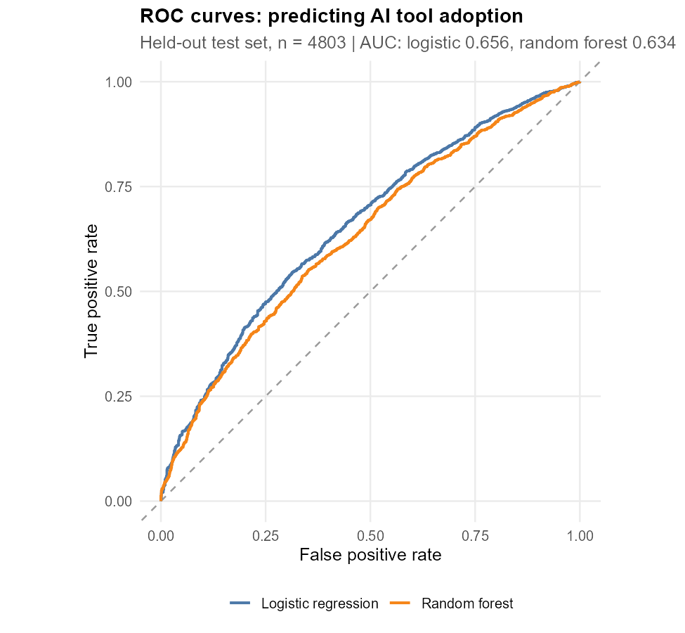

ROC curves

```r
fig("15_roc_curves")
```

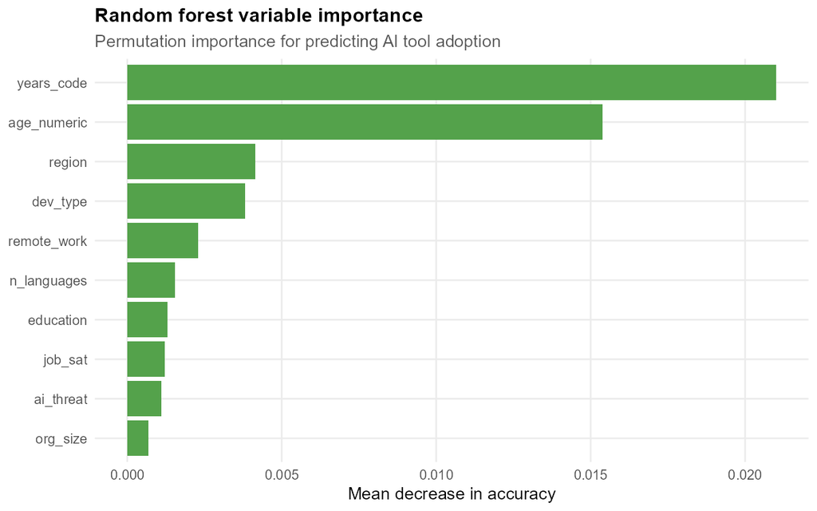

Random forest importance

```r
fig("16_rf_importance")
```

The two models land close together, which is itself the finding: the relationship between professional attributes and AI adoption is mostly additive, so the random forest’s extra flexibility buys little. Both beat chance on AUC, but neither is a strong classifier: the ten professional attributes used here do not identify which individual adopts AI tools.

## 5.3 Six-model benchmark

The same split and predictors are extended to six models by `scripts/06_paper_benchmark.R`. Decision thresholds come from out-of-fold training predictions (Youden’s J). Accuracy is not used to rank the models, because the tuned thresholds put every model below the majority-class baseline.

```r
bp <- file.path("paper", "tables", "benchmark_metrics.csv")
pp <- file.path("paper", "tables", "benchmark_pvalues.csv")
if (file.exists(bp) && file.exists(pp)) {
  kable(readr::read_csv(bp, show_col_types = FALSE) %>%
          dplyr::select(model, threshold, accuracy, precision, recall,
                        specificity, f1, mcc, kappa, auc, cv_auc) %>%
          dplyr::mutate(dplyr::across(where(is.numeric), ~ round(.x, 3))),
        caption = "Six-model benchmark on the held-out test set")
  kable(readr::read_csv(pp, show_col_types = FALSE) %>%
          dplyr::mutate(dplyr::across(where(is.numeric), ~ signif(.x, 3))),
        caption = "Each model against logistic regression: AUC with DeLong 95% CI, DeLong, McNemar and Holm-adjusted p-values")
} else {
  cat("Run `Rscript scripts/06_paper_benchmark.R` to generate the benchmark tables.")
}
```

[output not shown]

Each model against logistic regression: AUC with DeLong 95% CI, DeLong, McNemar and Holm-adjusted p-values

| model | auc | lo | hi | delta | p_delong | p_mcnemar | p_holm |
| --- | --- | --- | --- | --- | --- | --- | --- |
| Logistic regression | 0.656 | 0.637 | 0.676 | NA | NA | NA | NA |
| Random forest | 0.634 | 0.614 | 0.654 | -0.022300 | 0.0102 | 2.65e-03 | 0.0408 |
| XGBoost | 0.666 | 0.647 | 0.685 | 0.009560 | 0.0425 | 4.16e-02 | 0.1270 |
| LightGBM | 0.657 | 0.638 | 0.676 | 0.000931 | 0.8700 | 4.27e-01 | 0.8700 |
| MLP (nnet) | 0.634 | 0.615 | 0.654 | -0.022000 | 0.0020 | 0.00e+00 | 0.0100 |
| Ensemble (soft vote) | 0.665 | 0.646 | 0.684 | 0.008320 | 0.0567 | 3.00e-07 | 0.1270 |

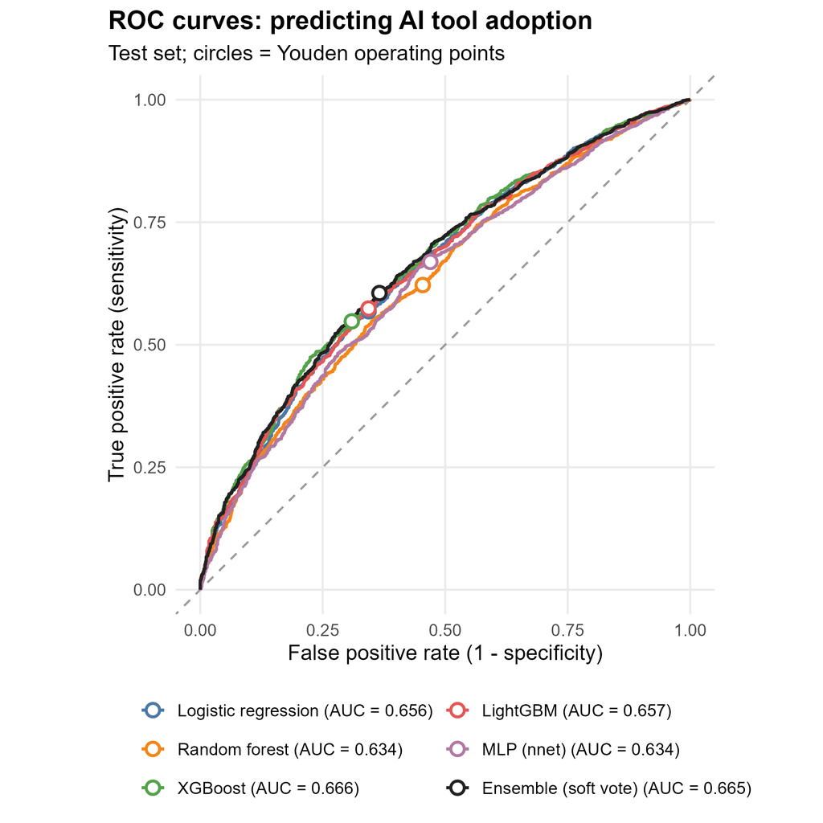

ROC curves of the six benchmarked models

```r
rp <- file.path("paper", "figures", "roc_comparison.png")
if (file.exists(rp)) knitr::include_graphics(normalizePath(rp))
```

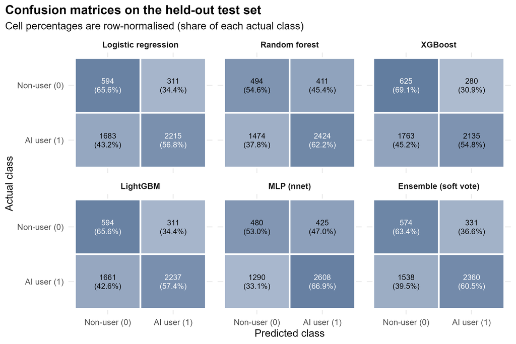

Row-normalised confusion matrices on the held-out test set

```r
cp <- file.path("paper", "figures", "confusion_matrices.png")
if (file.exists(cp)) knitr::include_graphics(normalizePath(cp))
```

## 5.4 What predicts trust in AI accuracy?

Trust is recorded on a five-point ordered scale. The chi-square tests above collapse it to a binary, which throws away the ordering; treating it as a number would assume the gap between “somewhat distrust” and “neither” equals the gap between “somewhat trust” and “highly trust”. A proportional-odds model (`MASS::polr`, n = 19,112) needs neither assumption.

```r
ord <- read_out("22_ordinal_trust_model")
kable(ord %>%
        dplyr::filter(kind == "predictor") %>%
        dplyr::arrange(dplyr::desc(abs(estimate))) %>%
        head(14) %>%
        dplyr::select(term, odds_ratio, conf_low, conf_high, p_value),
      caption = "Ordinal logistic regression on trust. Odds ratio > 1 means higher trust.")
```

Ordinal logistic regression on trust. Odds ratio > 1 means higher trust.

| term | odds_ratio | conf_low | conf_high | p_value |
| --- | --- | --- | --- | --- |
| dev_typeRetired | 28.8909 | 0.6544 | 1275.5673 | 0.0818 |
| ai_usageDaily | 11.1860 | 10.3135 | 12.1322 | 0.0000 |
| ai_usageWeekly | 5.2556 | 4.7999 | 5.7545 | 0.0000 |
| regionOceania | 0.3259 | 0.2546 | 0.4171 | 0.0000 |
| regionNorth America | 0.3503 | 0.2855 | 0.4297 | 0.0000 |
| dev_typeFounder, technology or otherwise | 2.7912 | 1.7604 | 4.4256 | 0.0000 |
| dev_typeData or business analyst | 2.7080 | 1.5069 | 4.8666 | 0.0009 |
| dev_typeProject manager | 2.6043 | 1.4569 | 4.6552 | 0.0012 |
| regionEurope | 0.3956 | 0.3238 | 0.4832 | 0.0000 |
| ai_usageMonthly/rarely | 2.4272 | 2.2047 | 2.6722 | 0.0000 |
| dev_typeDeveloper, QA or test | 2.1669 | 1.4096 | 3.3311 | 0.0004 |
| dev_typeAI/ML engineer | 2.1402 | 1.4842 | 3.0861 | 0.0000 |
| dev_typeSystem administrator | 2.1196 | 1.1171 | 4.0217 | 0.0215 |
| dev_typeCybersecurity or InfoSec professional | 1.9705 | 1.2027 | 3.2284 | 0.0071 |

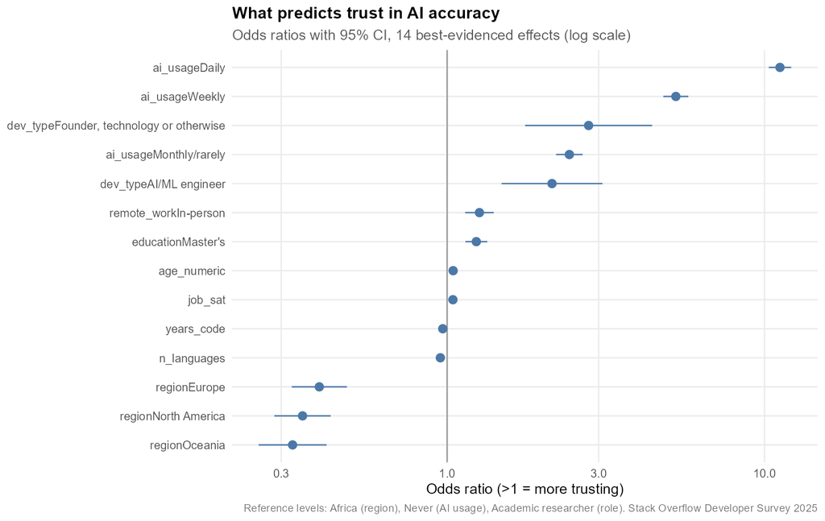

Predictors of trust in AI accuracy

```r
fig("22_ordinal_trust_effects")
```

Usage dominates everything else: daily users have 11.2x the odds of a higher trust rating than people who do not currently use AI tools. Experience pushes the other way — each additional year of coding multiplies the odds by 0.969, which compounds to roughly 27% lower odds over a decade. The direction of causation is not identified here: trusting the tools and using them daily reinforce each other.

```r
po <- read_out("23_proportional_odds_check")
kable(head(po, 8),
      caption = "Proportional-odds check: coefficients refitted at each of the four cut-points.")
```

Proportional-odds check: coefficients refitted at each of the four cut-points.

| term | mean_estimate | sd_estimate | unstable |
| --- | --- | --- | --- |
| dev_typeRetired | 6.5638 | 8.7727 | TRUE |
| dev_typeSystem administrator | 1.1570 | 0.8372 | FALSE |
| dev_typeAI/ML engineer | 0.8402 | 0.5240 | FALSE |
| ai_usageWeekly | 1.4454 | 0.5067 | FALSE |
| dev_typeCybersecurity or InfoSec professional | 0.7196 | 0.4485 | FALSE |
| dev_typeSenior executive (C-suite, VP, etc.) | 0.2885 | 0.4452 | TRUE |
| dev_typeOther (please specify): | 0.3466 | 0.3655 | TRUE |
| dev_typeDeveloper, game or graphics | 0.4083 | 0.2953 | FALSE |

The assumption holds for the terms the conclusions rest on: 10 of 46 coefficients vary more across cut-points than their own size. Four are sparse role categories (retired, senior executives, “other”, cloud infrastructure engineers) and six are terms with near-zero average effect (Asia and Middle East, bachelor’s, doctorate, medium and large organisations, language count). Usage frequency, years of coding, age and the North America, Europe and Oceania contrasts are stable.

# 6 Developer personas

k-means on nine standardised AI-attitude and experience variables, with *k* chosen by average silhouette width. PCA is used only to display the structure, not as input to k-means.

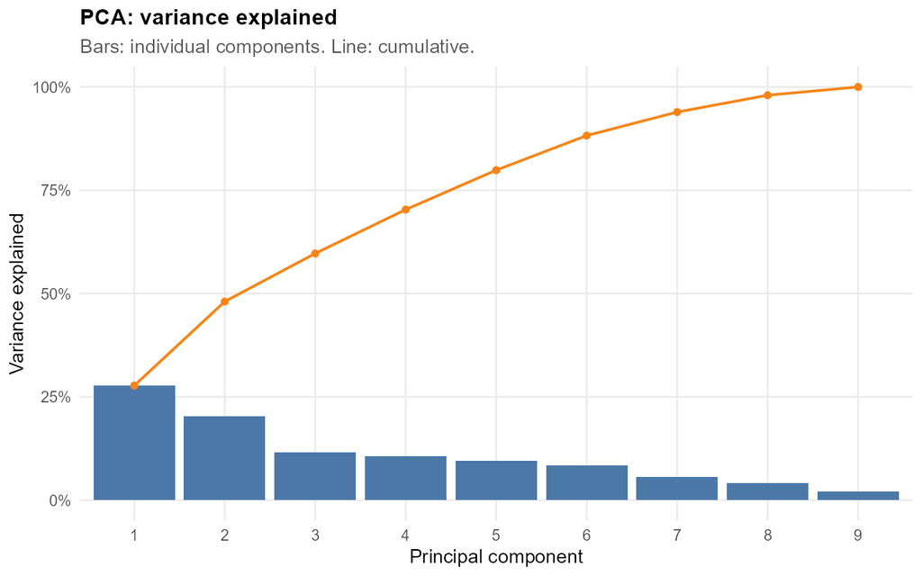

PCA scree plot

```r
fig("17_pca_scree")
```

```r
kable(read_out("16_pca_loadings"), caption = "PCA loadings, first three components")
```

PCA loadings, first three components

| variable | PC1 | PC2 | PC3 |
| --- | --- | --- | --- |
| years_code | 0.083 | -0.692 | -0.047 |
| age_numeric | 0.020 | -0.698 | 0.080 |
| job_sat | -0.076 | -0.160 | -0.389 |
| n_languages | 0.066 | 0.043 | -0.829 |
| ai_sent_score | -0.520 | -0.065 | 0.028 |
| ai_trust_score | -0.503 | -0.026 | 0.152 |
| ai_daily | -0.438 | 0.021 | -0.114 |
| ai_agent_user | -0.284 | -0.018 | -0.335 |
| ai_complex_ok | -0.432 | -0.031 | 0.062 |

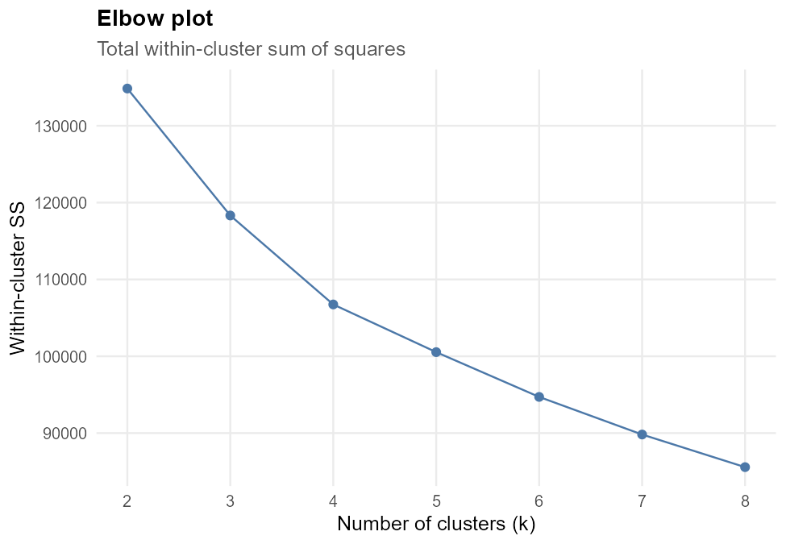

Elbow plot

```r
fig("18_kmeans_elbow")
```

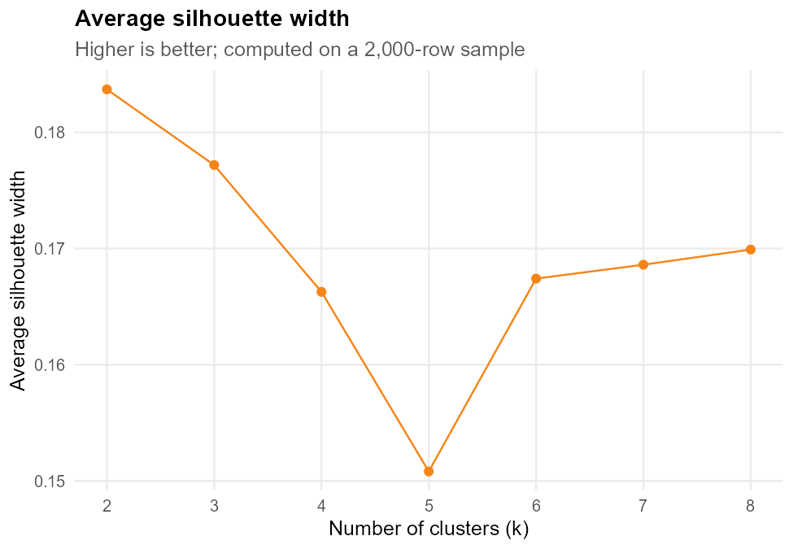

Silhouette widths

```r
fig("19_kmeans_silhouette")
```

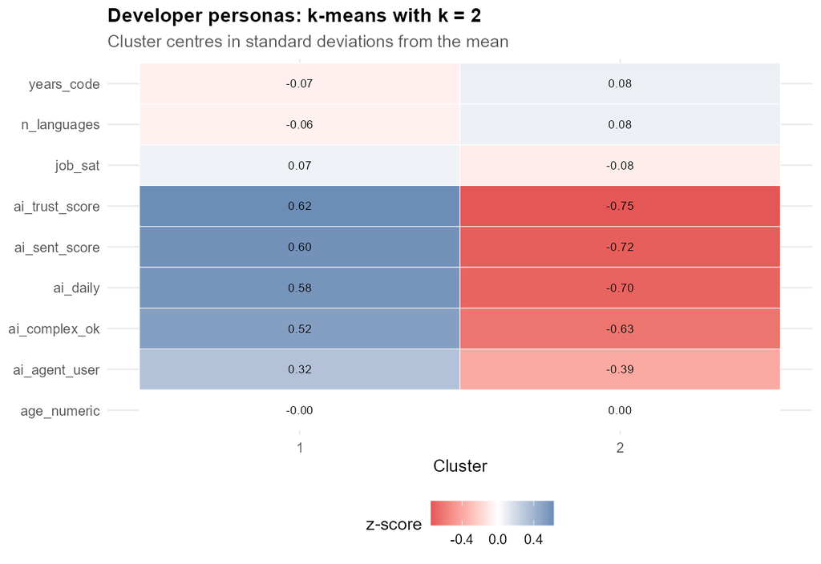

Cluster centres

```r
fig("20_cluster_centres")
```

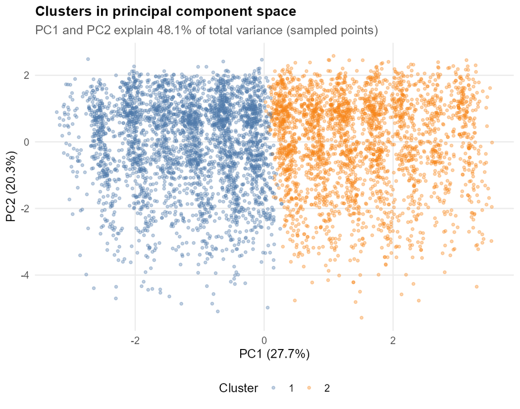

Clusters in PC space

```r
fig("21_cluster_pca")
```

```r
kable(read_out("18_cluster_profiles"), caption = "Cluster profiles, original units")
```

Cluster profiles, original units

| cluster | n | share | years_code | age_numeric | job_sat | n_languages | ai_sent_score | ai_trust_score | ai_daily | ai_agent_user | ai_complex_ok |
| --- | --- | --- | --- | --- | --- | --- | --- | --- | --- | --- | --- |
| 1 | 10162 | 54.5 | 16.92 | 36.42 | 7.37 | 6.00 | 4.42 | 3.51 | 0.87 | 0.51 | 0.58 |
| 2 | 8476 | 45.5 | 18.50 | 36.43 | 7.07 | 6.44 | 2.98 | 1.95 | 0.24 | 0.17 | 0.04 |

### 6.0.1 How solid is this split?

Two checks, and they disagree in an informative way.

```r
stab <- read_out("24_cluster_stability")
kable(stab, caption = "Silhouette width and resampling stability")
```

Silhouette width and resampling stability

| runs | mean_ari | sd_ari | min_ari | silhouette |
| --- | --- | --- | --- | --- |
| 25 | 0.998 | 0.002 | 0.993 | 0.184 |

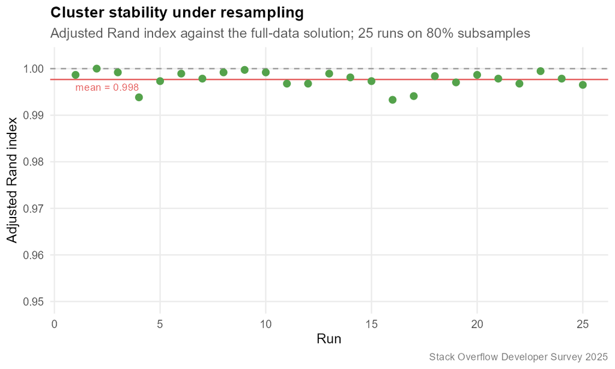

Cluster stability under resampling

```r
fig("23_cluster_stability")
```

The **silhouette width is 0.184** — below the 0.25 that Kaufman and Rousseeuw call the threshold for “substantial structure”. Taken alone, that says the two groups are not cleanly separated blobs.

The **adjusted Rand index is 0.998** across 25 runs on 80% subsamples (minimum 0.993), meaning a re-clustered subsample reproduces almost exactly the same partition.

Read together: developers lie on a continuum of AI attitude with no gap in the middle, but the line k-means draws through that continuum is in a stable, reproducible place. The split is a real description, not a separate-species claim — and the validation below shows it predicts variables it never saw.

```r
kable(read_out("19_cluster_validation"),
      caption = "Validation on variables that were not used to build the clusters")
```

Validation on variables that were not used to build the clusters

| cluster | n | median_salary | pct_remote | pct_large_org | pct_ai_threat_yes |
| --- | --- | --- | --- | --- | --- |
| 1 | 10162 | 73686 | 36.7 | 29.7 | 17.3 |
| 2 | 8476 | 83668 | 33.9 | 33.7 | 10.7 |

The validation table is the point of this section: salary, remote work and organisation size were deliberately excluded from the clustering features, so differences across clusters on those variables are evidence that the personas capture something real rather than an artefact of the algorithm.

# 7 Limitations

- **Self-selected sample.** Respondents are Stack Overflow visitors who chose to answer; they over-represent North America and Europe, so nothing here generalises to the whole developer population.
- **Cross-sectional.** Every association is correlational. Higher earners using AI more does not mean AI raised anyone’s salary; both are downstream of employer, seniority and country.
- **Converted compensation.** `ConvertedCompYearly` depends on exchange rates and self-reported figures, and the currency conversion date is not exposed.
- **Collapsed categories.** Grouping 175 countries into 7 regions and 8 education levels into 4 loses real variation. It trades precision for models that fit and tests that have adequate cell counts.
- **Large n.** Statistical significance is nearly guaranteed at this sample size; effect sizes are the honest summary.
- **Missingness is addressed, not eliminated.** The inverse-probability weighting corrects for reporting patterns that the *observed* predictors explain. If people hide their salary for reasons unrelated to region, role or experience — being unusually badly paid, say — that bias remains.
- **Prediction is weak.** The best AUC for adoption is 0.666 across six models, and no model is reliably better than logistic regression after Holm correction; the ten predictors used here carry little information about which individual adopts AI tools.

# 8 Reproducing this report

```bash
Rscript scripts/00_setup.R     # install packages, download data (~141 MB)
Rscript scripts/run_all.R      # clean, analyse, model, render this report
```

All randomness is seeded (`SEED = 42` in `R/setup.R`), so reruns reproduce the same splits, folds and clusters.